# GSA Competition

Ryan Tuggle

April 12, 2016

This R Markdown document shows an initial exploration of GSA contracting competition data.

Start with the sample of contracts.

```r
df <- read.csv('~/Repositories/data/GSA_Competition_Q1FY14.csv')
names(df)
```

```
##  [1] "Modification.Number"
##  [2] "PIID"
##  [3] "PIID.Agency.ID"
##  [4] "Referenced..IDV.PIID"
##  [5] "Referenced.IDV.Agency.ID"
##  [6] "Referenced.IDV.Mod.Number"
##  [7] "Solicitation.ID"
##  [8] "Transaction.Number"
##  [9] "Date.Signed"
## [10] "Effective.Date"
## [11] "Est..Ultimate.Completion.Date"
## [12] "Fiscal.Year"
## [13] "Funding.Agency.ID"
## [14] "Funding.Agency.Name"
## [15] "Funding.Department.ID"
```

[output cut: 61 more lines]

Take a look at how the extent competed variable is aggregated across mods. One goal is to understand how to sum up the competition variables such as the Number of Offers Received.

```r
library(dplyr)
#select variables for exploration
dfs <- select(df, Referenced..IDV.PIID, PIID, Referenced.IDV.Mod.Number, Modification.Number, Date.Signed, Extent.Competed, Number.of.Offers.Received, Other.Than.Full.and.Open.Competition, Action.Obligation, Actions, Number.of.Records, Contracting.Office.Name, Award.or.IDV.Type, Contracting.Agency.Name)

dfs <- mutate(dfs, Action.Obligation = as.numeric(Action.Obligation), cat = paste(Referenced..IDV.PIID, PIID, sep='-'))

test1 <- filter(dfs, Number.of.Records > 1 | Actions > 1)
View(test1)

#group variables by PIIDs
dfg <- group_by(dfs, cat)

test2 <- dfg %>%
    summarize(cnt = n_distinct(cat)) %>%
    arrange(desc(cnt)) %>%
    filter(cnt > 1)

head(test2)
```

```
## Source: local data frame [0 x 2]
##
## Variables not shown: cat (chr), cnt (int)
```

```r
#does any PIID have a mod in this set?
test3 <- filter(dfs, Modification.Number != 0)
tbl_df(sample_n(test3, 20))
```

```
## Source: local data frame [20 x 15]
##
##    Referenced..IDV.PIID           PIID Referenced.IDV.Mod.Number
##                  (fctr)         (fctr)                    (fctr)
## 1                           GS35F0525K
## 2        GS07P08HHD0060  GSP0713UK5028                         0
## 3                           GS02F0177W
## 4                           GS02F197AA
## 5                           GS10F8699G
## 6                           GS35F0196V
## 7                           GS10F0327Y
## 8                           GS35F0460V
## 9                           GS07F0456X
## 10                          GS27F0013J
## 11                          GS35F0441J
## 12                      GS08P13VLC0021                         0
## 13                          GS35F0107X
## 14                          GS33FBA004
## 15                          GS10F0243W
## 16                      GS03P11QMC0021
## 17           GS07F0420T  GSP0413RD0086                         0
## 18                          GS23F0424K
## 19                          GS10F0026J
## 20                          GS02F097AA
## Variables not shown: Modification.Number (fctr), Date.Signed (fctr),
##   Extent.Competed (fctr), Number.of.Offers.Received (int),
##   Other.Than.Full.and.Open.Competition (fctr), Action.Obligation (dbl),
##   Actions (int), Number.of.Records (int), Contracting.Office.Name (fctr),
##   Award.or.IDV.Type (fctr), Contracting.Agency.Name (fctr), cat (chr)
```

Next let’s look at a few dimensions of the dataset.

Start with the count of records by contracting Agency

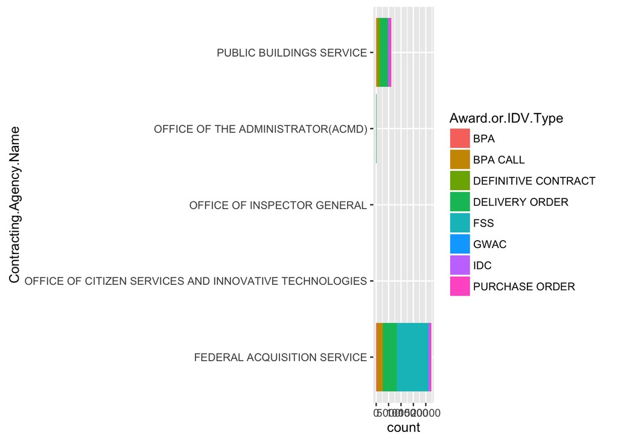

```r
#contracting agency
library(ggplot2)
ggplot(dfs, aes(Contracting.Agency.Name)) +
    geom_bar(aes(fill = Award.or.IDV.Type)) +
    coord_flip()
```

Drill down to the offices within the Federal Acquisition Service

[figure not shown]

```r
#contracting agency
library(ggplot2)
ggplot(filter(dfs, Contracting.Agency.Name == 'FEDERAL ACQUISITION SERVICE'),
              aes(Contracting.Office.Name)) +
    geom_bar(aes(fill = Award.or.IDV.Type)) +
    coord_flip()
```

Looks like Federal Supply Schedules (FSS) make up the majority of the contract actions. Believe these are a vehicle and so too BPA and IDC, probably want to add category for Award or vehicle type. First, let’s get the overall percentages by type.

```r
pct <- dfs %>%
    group_by(Award.or.IDV.Type) %>%
    summarise(cnt = n(), value = sum(Action.Obligation)) %>%
    mutate(propCnt = cnt / sum(cnt), propSum = value / sum(value))

tbl_df(pct)
```

```
## Source: local data frame [8 x 5]
##
##     Award.or.IDV.Type   cnt    value      propCnt      propSum
##                (fctr) (int)    (dbl)        (dbl)        (dbl)
## 1                 BPA   518   448036 0.0182529335 6.576416e-03
## 2            BPA CALL  2618 13158707 0.0922513126 1.931477e-01
## 3 DEFINITIVE CONTRACT  1302  3828592 0.0458789950 5.619730e-02
## 4      DELIVERY ORDER  8742 34523821 0.3080446809 5.067517e-01
## 5                 FSS 12781 10212019 0.4503682300 1.498953e-01
## 6                GWAC     4     3196 0.0001409493 4.691191e-05
## 7                 IDC  1192  1511973 0.0420028895 2.219322e-02
## 8      PURCHASE ORDER  1222  4441340 0.0430600092 6.519141e-02
```

Seventy five percent of the records are FSS (45%) or Delivery Order (30%). Seventy percent of the funding comes from Delivery Order (50%) and BPA Calls (19%).

While we’re looking at percentages let’s take a similar look at the break down of competition types.

```r
pct <- dfs %>%
    group_by(Extent.Competed) %>%
    summarise(cnt = n(), value = sum(Action.Obligation)) %>%
    mutate(propCnt = cnt / sum(cnt), propSum = value / sum(value))

tbl_df(pct)
```

```
## Source: local data frame [10 x 5]
##
##                                         Extent.Competed   cnt    value
##                                                  (fctr) (int)    (dbl)
## 1                                                         279   326843
## 2                                    COMPETED UNDER SAP  1408  6277719
## 3                            COMPETITIVE DELIVERY ORDER   107   193341
## 4                          FOLLOW ON TO COMPETED ACTION     8    32211
## 5                             FULL AND OPEN COMPETITION 21509 44986631
## 6  FULL AND OPEN COMPETITION AFTER EXCLUSION OF SOURCES  2162  5778656
## 7                        NON-COMPETITIVE DELIVERY ORDER     7     9246
## 8                         NOT AVAILABLE FOR COMPETITION  2010  7616684
## 9                                          NOT COMPETED   256   671682
## 10                               NOT COMPETED UNDER SAP   633  2234671
## Variables not shown: propCnt (dbl), propSum (dbl)
```

Seventy five percent of the records are listed as completely full and open. Only sixty six percent when weighted by dollars.

Now we should start to explore patterns in the number of offers…